# Laboratorio di Programmazione Gr. 3 (N-Z)

# Corso di Laurea in Informatica

## Università degli Studi di Napoli Federico II

## A.A. 2021/22

# **Le Funzioni**

Si desidera implementare in C un programma *CalcolatriceCarina* che, dati gli operandi, visualizzi il risultato delle 4 operazioni base (+,-,/,x) circondato da una cornice di asterischi.

```
dammi in primo operando
4
dammi il secondo operando
2
la somma di 4.00 e 2.00 e'
*********************
**         6.00    **
*********************
la differenza tra 4.00 e 2.00 e'
*********************
**         2.00    **
*********************
il prodotto tra 4.00 e 2.00 e'
*********************
**          8.00   **
*********************
il quoziente tra 4.00 e 2.00 e'
*********************
**          2.00   **
*********************
```

```python
#include <stdio.h>
int main()
{
    float op1;
    float op2;
    float ris;
    printf("dammi in primo operando\n");
    scanf("%f", &op1);
    printf("dammi il secondo operando\n");
    scanf("%f", &op2);
    printf("la somma di %.2f e %.2f e'\n", op1, op2);
    ris = op1 + op2;
    printf("**********************\n");
    printf("%s%*.2f%*s\n", "**",  10,ris , 10,"**");
    printf("**********************\n");
    printf("la differenza tra %.2f e %.2f e'\n", op1, op2);
    ris = op1 - op2;
    printf("**********************\n");
    printf("%s%*.2f%*s\n", "**",  10,ris , 10,"**");
    printf("**********************\n");
    printf("il prodotto tra %.2f e %.2f e'\n", op1, op2);
    ris = op1 * op2;
    printf("**********************\n");
    printf("%s%*.2f%*s\n", "**",  10,ris , 10,"**");
    printf("**********************\n");
    printf("il quoziente tra %.2f e %.2f e'\n", op1, op2);
    ris = op1 / op2;
    printf("**********************\n");
    printf("%s%*.2f%*s\n", "**",  10,ris , 10,"**");
    printf("**********************\n");
    return 0;
}
```

```
dammi in primo operando
```

```
dammi il secondo operando
```

[output not shown]

#### Lo stesso codice ripetuto più volte!

```
#include <stdio.h>
int main()
{
    float op1;
    float op2;
    float ris;
    printf("dammi in primo operando\n");
    scanf("%f", &op1);
    printf("dammi il secondo operando\n");
    scanf("%f", &op2);
    printf("la somma di %.2f e %.2f e'\n", op1, op2);
    ris = op1 + op2;
```

```
printf("**********************\n");
    printf("%s%*.2f%*s\n", "**",  10,ris , 10,"**");
    printf("**********************\n");
```

```
printf("la differenza tra %.2f e %.2f e'\n", op1, op2);
    ris = op1 - op2;
```

```
printf("**********************\n");
    printf("%s%*.2f%*s\n", "**",  10,ris , 10,"**");
    printf("**********************\n");
```

```
printf("il prodotto tra %.2f e %.2f e'\n", op1, op2);
    ris = op1 * op2;
```

```
printf("**********************\n");
    printf("%s%*.2f%*s\n", "**",  10,ris , 10,"**");
    printf("**********************\n");
```

```
printf("il quoziente tra %.2f e %.2f e'\n", op1, op2);
    ris = op1 / op2;
```

```
printf("**********************\n");
    printf("%s%*.2f%*s\n", "**",  10,ris , 10,"**");
    printf("**********************\n");
```

```
return 0;
}
```

#### - Definisco una funzione col codice ripetuto

```
#include <stdio.h>

void incornicia(float numero)
{
    printf("**********************\n");
    printf("%s%*.2f%*s\n", "**",  10,numero , 10,"**");
    printf("**********************\n");

}
```

#### - Invoco la funzione

```
int main()
{
    float op1;
    float op2;
    float ris;
    printf("dammi in primo operando\n");
    scanf("%f", &op1);
    printf("dammi il secondo operando\n");
    scanf("%f", &op2);
    printf("la somma di %.2f e %.2f e'\n", op1, op2);
    ris = op1 + op2;
    incornicia(ris);
    printf("la differenza tra %.2f e %.2f e'\n", op1, op2);
    ris = op1 - op2;
    incornicia(ris);
    printf("il prodotto tra %.2f e %.2f e'\n", op1, op2);
    ris = op1 * op2;
    incornicia(ris);
    printf("il quoziente tra %.2f e %.2f e'\n", op1, op2);
    ris = op1 / op2;
    incornicia(ris);
  }
```

### L'output effettivo è identico al precedente.

# **I parametri: perchè?**

Le variabili dichiarate all'interno di un blocco **non sono visibili** (ossia non sono accessibili) all'esterno del blocco in cui sono dichiarate

| Definizione | Invocazione |
| --- | --- |
| ```c void incornicia( ) { printf("**********************\n"); printf("%s%*.2f%*s\n", "**", 10, x , 10,"**"); printf("**********************\n"); } ``` | ```c int main() { float x = 10; Incornicia( ); } ``` |

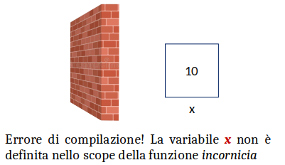

Potrei pensare di dichiarare una nuova variabile in incornicia, MA...

| Definizione | Invocazione |
| --- | --- |
| ```c void incornicia( ) { float x; printf("*********************\n"); printf("%s%*.2f%*s\n", "**",10,x, 10,"**"); printf("*********************\n"); } ``` | ```c int main() { float x = 10; Incornicia( ); } ``` |

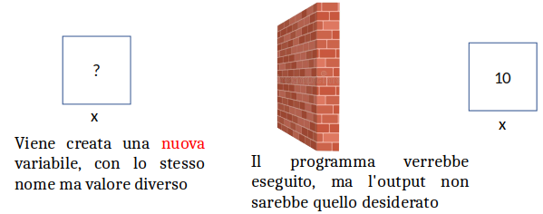

**NECESSARIO UN SISTEMA DI COMUNICAZIONE TRA BLOCCHI** $\Rightarrow$ utilizzo dei parametri!

# **I parametri: come?**

| Definizione | Invocazione |
| --- | --- |
| ```c void incornicia(float numero) { printf("**********************\n"); printf("%s%*.2f%*s\n", "**",10,numero, 10,"**"); printf("**********************\n"); } ``` | ```c int main() { float x = 10; Incornicia( x ); } ``` |

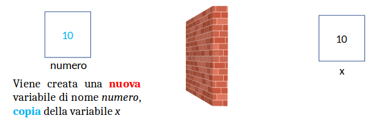

> **parametri formali**: parametri dichiarati come parte *dichiarazione/definizione* della funzione

> **parametri attuali**: parametri passati durante l'*invocazione* della funzione

Nello standard C è più corretto parlare di *parametri* e *argomenti*, rispettivamente al posto di *parametri formali* e *parametri attuali*.

# **Ritorno al chiamante**

Il meccanismo del passaggio di parametri permette di copiare valori dall' *invocante* all'*invocato*, ma non viceversa.

Problema: implementare un programma che, data base ed altezza, stampi a video l'area ed il perimetro di un rettangolo

```
#include <stdio.h>
int main()
{
    float b, h;
    float area, perimetro;
    printf("inserire il valore della base\n");
    scanf("%f", &b);
    printf("inserire il valore dell'altezza\n");
    scanf("%f", &h);
    area = b * h;
    perimetro = 2*b + 2*h;
    printf("l'area è %.2f \n", area);
    printf("il perimetro è %.2f \n", perimetro);
}
```

#### Una prima soluzione **sbagliata**

[output not shown]

La tecnica del passaggio di parametri, in C, è definita **solo per copia**. Tale copia viene eseguita soltanto all'atto dell'invocazione della funzione dal chiamante al chiamato, e non alla fine dal chiamato al chiamante!

[output not shown]

Il valore che segue la parola chiave `return` viene copiato all'interno della variabile a sinistra dell'assegnazione nell'invocante (o in un'eventuale espressione). Se una funzione restituisce un valore attraverso la parola chiave `return`, il tipo di ritorno deve essere dello stesso tipo del valore restituito (e non più `void`)

### **In generale**:

Una funzione in *C* viene **dichiarata/definita** nel seguente modo:

```
tipo_ritorno nome_fun(tipo_param1 nome_param1,
                          tipo_param2 nome_param2, ...)
    {
        ...corpo...
        return valore_ritorno;
    }
```

- tutto ciò che viene prima della `{` è detto **header**
- la lista dei parametri (formali) è composta da **dichiarazioni di variabili** (quindi compresa di tipo) separati da `,`
- il tipo di ritorno deve corrispondere al tipo del valore di ritorno. In caso contrario, il valore di ritorno sarà convertito nel tipo di ritorno.
- nel caso in cui non sia necessario che la funzione restituisca un valore, *tipo_ritorno* può essere `void` e la parola chiave `return` può essere omessa (o lasciata senza valore, ossia `return;`)
- I valori che assumono i parametri in fase di invocazione sono detti **parametri attuali**
- una funzione può anche solo essere *dichiarata* senza essere (ancora) definita esplicitando l'header seguito da un `;`. Esempio:

  ```
  tipo_ritorno nome_fun(tipo_param1 nome_param1,
                          tipo_param2 nome_param2, ...);
  ```

  La *dichiarazione* senza definizione di una funzione serve a segnalare che esiste(rà) una funzione di nome `nome_fun` avente parametri di tipo `tipo_param1, tipo_param2,...`, la cui *definizione* è specificata altrove.

```python
#include <stdio.h>
int f()
{
    double a = 3.5;
    return a;
}

int main()
{
    double r = f(); // invocazione
    printf("%f\n",r);

    return 0;
}
```

```
3.000000
```

```python
#include <stdio.h>
void stampa_doppio(int n)
{
    printf("%d",n*2);
}

int main()
{
    stampa_doppio(4); //invocazione

    return 0;
}
```

```
8
```

L'invocazione di una funzione che restituisce un valore presuppone che tale invocazione sia fatta all'interno di una espressione o un'assegnazione.

Esempio:

```
double quadrato(double l)
    {
        return l*l;
    }

    int main()
    {
        int q = quadrato(10);
        printf("il quadrato di 10 è %d\n",q);

        printf("il quadrato di 3 è %d\n", quadrato(3));

        int l = q + quadrato(3);

        printf("la loro somma è %d\n", l);

        return 0;
    }
```

da notare:

- non salvare `quadrato(3)` in una variabile non è convenuto, in quanto l'ho dovuto ricalcolare con una seconda invocazione
- l'object `int l` dichiarato nel corpo del `main()` non ha nulla a che vedere con il `double l` dichiarato come parametro della funzione `quadrato(double l)`. Gli object dichiarati nel corpo di una funzione sono visibili solo all'interno di quest'ultima $\rightarrow$ Gli *scope* sono separati (anche per questo sono necessari i parametri)
- `return` esce dalla funzione in esecuzione (anche se quest'ultima non è terminata, quindi attenzione a dove viene messa!)

```python
# include <stdio.h>
//Esempio:
double calcola_media(double a, double b)
{
    double media = a + b;
    return media;
    media = media / 2.0;
}

int main()
{
    printf("la media tra 2 e 3 è %f\n", calcola_media(2,3));
    return 0;
}
```

```
la media tra 2 e 3 è 5.000000
```

```python
# include <stdio.h>
double calcola_valore_assoluto(double n)
{
    if( n >= 0 )
    {
        return n;
    }
    else
    {
        return -n;
    }
}

int main()
{
    printf("il valore assoluto di -4 è %f\n",
               calcola_valore_assoluto(-4));
    return 0;
}
```

```
il valore assoluto di -4 è 4.000000
```

# La **funzione** main()

il cosiddetto `main()` è una funzione a tutti gli effetti.

`main()` è la funzione che viene invocata all'atto dell'esecuzione del programma (*entry point*). Sarà quindi sua cura invocare al suo interno le funzioni che devono essere a loro volta utilizzate nel programma (se necessario). Niente vieta di dichiarare/definire funzioni senza mai invocarle.

In quanto funzione:

- viene dichiarata con tipo di ritorno (`int`, in versioni di C precedenti era accettato anche `void`)
- restituisce un valore (per questo `return 0;`) al termine della sua esecuzione, che corrisponde al termine del programma.
- può anche avere parametri, ma lo vedremo più in là

Perchè proprio $0$?

### **Exit code**

Solitamente il valore di ritorno della funzione `main()` (o anche *exit code*) è un intero tra $0$ e $255$ che può servire al sistema operativo ad innescare determinate operazioni una volta terminato il programms. Se il programma termina correttamente ci si aspetta che tale valore sia $0$, se invece ci sono stati errori il valore di ritorno potrebbe essere $\neq 0$.

Se si desidera visualizzare l'exit code dell'ultimo programma mandato in esecuzione, dare il comando linux `echo $?`

```python
# include <stdio.h>
int main()
{
    return 34;
}
```

```
[C kernel] Executable exited with code 34
```

# **Il call stack**

```python
# include <stdio.h>

double get_somma(double a, double b)
{
    double ret = a + b;
    return ret;
}

double get_media(double a, double b)
{
    double s;
    s          = get_somma(a, b);
    double ret;
    ret        = s/2.0;
    return ret;
}

int main()
{
    double a = 5;
    double b = 8;
    double m;
    m        = get_media(a,b);
    printf("la media tra %.2lf e %.2lf è %.2lf\n",a,b,m);

    return 0;
}
```

```
la media tra 5.00 e 8.00 è 6.50
```

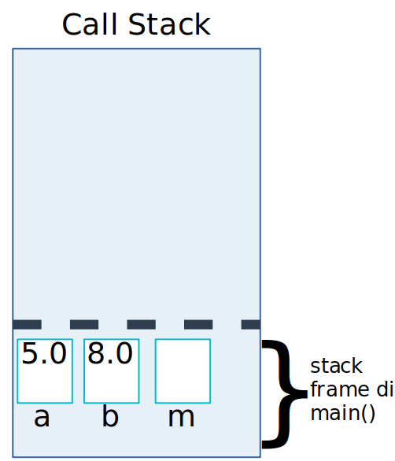

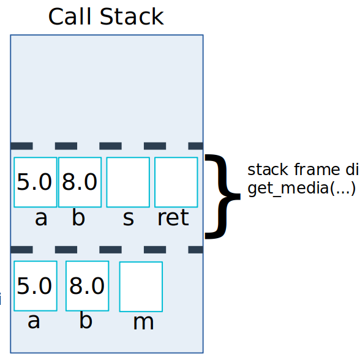

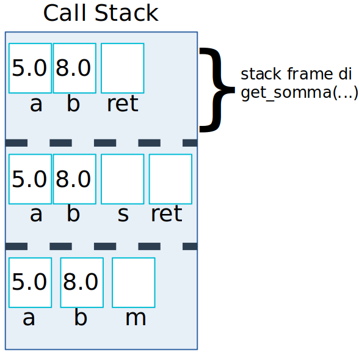

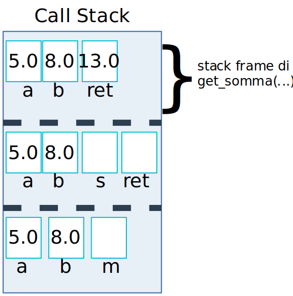

[figure not shown]

[figure not shown]

Ogni volta che viene invocata una funzione, viene impegnato un frammento (Stack Frame) del *call stack*. Tale frammento conterrà:

- le variabili locali della funzione
- eventuali parametri attuali
- dati (e.g.,l'indirizzo di ritorno) per ripristinare lo stato al programma al termine della funzione Ogni stack frame verrà eliminato dal call stack al termine della relativa funzione.

# **Parametri di uscita: come?**

### *Il problema dello scambio*

> Definire una funzione che, date due variabili, ne scambi il contenuto. Stampare quindi, nel chiamante, le variabili scambiate

Versione senza funzioni:

```
#include <stdio.h>
int main()
{
    int a;
    int b;
    int t;  // necessaria per lo scambio
    printf("dammi il valore della variabile a\n");
    scanf("%d", &a);
    printf("dammi il valore della variabile b\n");
    scanf("%d", &b);
    t = a;
    a = b;
    b = t;
    printf("dopo lo scambio a vale %d e b vale %d\n", a, b);
}
```

### Una soluzione **sbagliata**

[output not shown]

Il programma, compilato ed eseguito, **non** scambierà il contenuto delle variabili.

[output not shown]

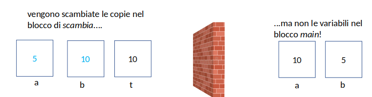

Le variabili `a,b,t` sono variabili *locali* del metodo `scambia(...)`, mentre le variabili `a,b` sono variabili *locali* del metodo `main()`

[output not shown]

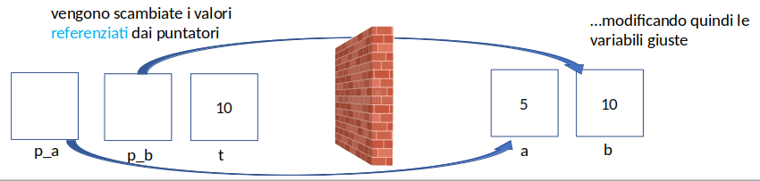

> Domanda: potevo risolvere lo stesso problema utilizzando la parola chiave `return`?

Risposta: **no**, in quanto con la parola chiave return, in *C*, posso restituire **al più un valore**. In alternativa, avrei potuto restituire il valore di una variabile con `return` (es. `return a;`), e modificare l'altra (es. `b`) con un puntatore

> Domanda: quindi posso utilizzare la tecnica del passaggio di parametri per puntatori e del return nella stessa funzione?

Risposta: **sì**, sono due cose totalmente diverse, quindi possono essere utilizzate tranquillamente assieme.

### **Passaggio di array allocati tramite operatore `[]` ad una funzione**

Il passaggio di parametri di array è da considerarsi sempre *per riferimento*

```
void f(int V[10], int n)
{
    for(int i=0; i < n; i++)
    {
        scanf("%d", &V[i]);
    }
}

int main()
{
    int n;
    int vett[10];
    printf("quanti elementi vuoi inserire?");
    scanf("%d", &n);

    f(vett,n);

    printf("i valori inseriti sono:\n");
    for(int i=0; i < n; i++)
    {
        printf("%d ", vett[i]);
    }
    printf("\n");
    return 0;
}
```

Questo perchè il nome simbolico del vettore `vett` si riferisce sempre all' *indirizzo* del vettore, quindi "passare" un vettore come parametro significa, di fatto, passare il suo indirizzo.

Analogamente, la dichiarazione del parametro `int V[10]` è simile alla dichiarazione di un puntatore. Volendo, la stessa funzione poteva essere definita come:

```
void f(int V[], int n)
{
    for(int i=0; i < n; i++)
    {
        scanf("%d", &V[i]);
    }
}
```

La dimensione, nel caso di array monodimensionali come parametro, non è necassaria. Dato che, all'atto pratico, ciò che viene passato è l'indirizzo ad un `int` (nello specifico, l'indirizzo del primo elemento dell'array), tale funzione poteva anche essere scritta come:

```
void f(int* V, int n)
{
    for(int i=0; i < n; i++)
    {
        scanf("%d", &V[i]);
    }
}
```

Discorso simile, **ma non identico**, con array multidimensionali:

```
void f(int M[10][3], int n_r, int n_c)
{
    for(int i=0; i < n_r; i++)
    {
        for(int j=0; j < n_c; j++)

        {scanf("%d", &M[i][j]);}
    }
}

int main()
{
    int n_r, n_c;
    int mat[10][3];
    printf("quante righe vuoi inserire?");
    scanf("%d", &n_r);
    printf("quante colonne vuoi inserire?");
    scanf("%d", &n_c);
    f(vett,n);

    printf("i valori inseriti sono:\n");
    for(int i=0; i < n_r; i++)
    {
        for(int j=0; j < n_c; j++)
            printf("%d ", mat[i][j]);
    }
    printf("\n");
    return 0;
}
```

MA... in questo caso la dichiarazione del parametro `int M[10][3]` come `int M[][]` non va bene!

Perchè?

semplifichiamo il problema analizzando la seguente funzione (sbagliata):

```
void f(int M[][])
{
    M[1][2] = 42; // dove finisce la riga 0
                  // e dove inizia la colonna 1??
}
```

ricordiamo che una matrice in memoria è rappresentata in maniera sequenziale in modalità row-major (in C). Senza conoscere il numero di colonne, come può la funzione determinare dove finisce la riga con indice `0` ed inizia la riga con indice `1` ? Fornire alla funzione almeno il numero di colonne è indispensabile. Quindi una versione corretta della funzione è la seguente:

```
void f(int M[][3])
{
    M[1][2] = 42;
}
```

Questa funzione è quindi valida per qualsiasi matrice avente 3 colonne, indipendentemente dal numero di righe che tale matrice abbia.

Come specificato quando si è parlato di puntatori, però, i nomi delle matrici (o più in generale gli array multidimensionali) allocate tramite l'operatore `[]` **non** possono essere visti come *pointers to pointers* (i.e. `**`), quindi una dichiarazione di parametro *formale* fatta come nella seguente funzione:

```
void f(int** M)
{
   ...
}
```

non sarebbe compatibile con un parametro *attuale* di tipo matrice allocata tramite operatore `[]`.

### **Passare un array ad una funzione per copia**

Se proprio indispensabile, c'è un trick per passare un vettore ad una funzione per copia. La tecnica consiste nell'incapsularlo in una struttura:

```
struct Involucro
{
    int vett[10];
}

void f(struct Involucro inv, int n)
{
    for(int i=0; i < n; i++)
    {
        scanf("%d", &(inv.vett[i]));
    }
}

int main()
{
    int n;
    struct Involucro t;
    printf("quanti elementi vuoi inserire?");
    scanf("%d", &n);

    f(t,n);

    printf("i valori inseriti sono:\n");
    for(int i=0; i < n; i++)
    {
        printf("%d ", t.vett[i]);
    }
    printf("\n");
    return 0;
}
```

Una struttura, in C, di default viene passata per copia, e quindi con essa viene **copiato** tutto il suo contenuto, compresi eventuali array definiti attraverso `[]`.

Questa funzione, quindi, farà ciò che ci aspettiamo che faccia??

Ovviamente la risposta è **no**, in quanto la struct `t` viene passata *per copia*.